# Example workflow

Kenneth Benoit and Paul Nulty

27 October 2016

This file demonstrates a basic workflow to take some pre-loaded texts and perform elementary text analysis tasks quickly. The **quanteda** package comes with a built-in set of inaugural addresses from US Presidents. We begin by loading quanteda and examining these texts. The `summary` command will output the name of each text along with the number of types, tokens and sentences contained in the text. Below we use R’s indexing syntax to selectivly use the summary command on the first five texts.

```r
require(quanteda)
?devtools::install_github

summary(inaugTexts)
```

```
##               Text Types Tokens Sentences
## 1  1789-Washington   626   1540        23
## 2  1793-Washington    96    147         4
## 3       1797-Adams   826   2584        37
## 4   1801-Jefferson   716   1935        41
## 5   1805-Jefferson   804   2381        45
## 6     1809-Madison   536   1267        21
## 7     1813-Madison   542   1304        33
## 8      1817-Monroe  1040   3696       121
## 9      1821-Monroe  1262   4898       129
## 10      1825-Adams  1004   3154        74
## 11    1829-Jackson   517   1210        25
## 12    1833-Jackson   499   1271        29
## 13   1837-VanBuren  1315   4175        95
## 14   1841-Harrison  1893   9178       210
```

[output cut: 43 more lines]

```r
summary(inaugTexts[1:5])
```

```
##              Text Types Tokens Sentences
## 1 1789-Washington   626   1540        23
## 2 1793-Washington    96    147         4
## 3      1797-Adams   826   2584        37
## 4  1801-Jefferson   716   1935        41
## 5  1805-Jefferson   804   2381        45
```

Indexing a single text from our character vector of inaugural addresses returns a single character vector – note that unlike strings in some other languages, in R this is an atomic unit of length one which cannot be sub-indexed further with bracket notation. Use the `substr` function to extract or replace substrings, and the `nchar` function to count the number of characters in a character vector of length one.

```r
oneText <- inaugTexts[1]
length(inaugTexts)
```

```
## [1] 57
```

```r
length(oneText)
```

```
## [1] 1
```

```r
nchar(oneText)
```

```
## 1789-Washington
##            8618
```

```r
nchar(inaugTexts[5:7])
```

```
## 1805-Jefferson   1809-Madison   1813-Madison
##          12907           7000           7156
```

One of the most fundamental text analysis tasks is tokenization. To tokenize a text is to split it into smaller units, most commonly words, which can be counted and to form the basis of a quantitative analysis. The quanteda package has a function for tokenization: `tokenize`. Examine the manual page for this function.

```r
?tokenize
```

**quanteda**’s tokenize function can be used on a simple character vector, a vector of character vectors, or a corpus. Here are some examples:

```r
tokenize("Today is Thursday in Canberra. It is yesterday in London.")
```

```
## tokenizedText object from 1 document.
## Component 1 :
##  [1] "Today"     "is"        "Thursday"  "in"        "Canberra"
##  [6] "."         "It"        "is"        "yesterday" "in"
## [11] "London"    "."
```

```r
vec <- c(one = "This is text one", two = "This, however, is the second text")
tokenize(vec)
```

```
## tokenizedText object from 2 documents.
## one :
## [1] "This" "is"   "text" "one"
##
## two :
## [1] "This"    ","       "however" ","       "is"      "the"     "second"
## [8] "text"
```

Consider the default arguments to the tokenize function. To remove punctuation, you should set the `removePunct` argument to be TRUE. We can combine this with the `toLower` function to get a cleaned and tokenized version of our text.

```r
tokenize(toLower(vec), removePunct = TRUE)
```

```
## tokenizedText object from 2 documents.
## one :
## [1] "this" "is"   "text" "one"
##
## two :
## [1] "this"    "however" "is"      "the"     "second"  "text"
```

Using this function with the inaugural addresses:

```r
require(dplyr)
inaugTokens <- tokenize(toLower(inaugTexts))
inaugTokens[2]
```

```
## $`1793-Washington`
##   [1] "fellow"         "citizens"       ","              "i"
##   [5] "am"             "again"          "called"         "upon"
##   [9] "by"             "the"            "voice"          "of"
##  [13] "my"             "country"        "to"             "execute"
##  [17] "the"            "functions"      "of"             "its"
##  [21] "chief"          "magistrate"     "."              "when"
##  [25] "the"            "occasion"       "proper"         "for"
##  [29] "it"             "shall"          "arrive"         ","
##  [33] "i"              "shall"          "endeavor"       "to"
##  [37] "express"        "the"            "high"           "sense"
##  [41] "i"              "entertain"      "of"             "this"
##  [45] "distinguished"  "honor"          ","              "and"
##  [49] "of"             "the"            "confidence"     "which"
##  [53] "has"            "been"           "reposed"        "in"
```

[output cut: 23 more lines]

Once each text has been split into words, we can use the `dfm` function to create a matrix of counts of the occurrences of each word in each document:

```r
inaugDfm <- dfm(inaugTokens)
```

```
##
##    ... indexing documents: 57 documents
```

```
##
##    ... indexing features:
```

```
## 9,174 feature types
```

```
##    ... created a 57 x 9174 sparse dfm
##    ... complete.
## Elapsed time: 0.332 seconds.
```

```r
trimmedInaugDfm <- trim(inaugDfm, minDoc = 5, minCount = 10)
```

```
## Removing features occurring fewer than 10 times: 7662
```

```
## Removing features occurring in fewer than 5 documents: 6786
```

```r
weightedTrimmedDfm <- weight(trimmedInaugDfm, type = "tfidf")

require(magrittr)
inaugDfm2 <- dfm(inaugTokens) %>% trim(minDoc=5, minCount=10) %>%
                 weight(type = "tfidf")
```

```
##
##    ... indexing documents: 57 documents
```

```
##
##    ... indexing features:
```

```
## 9,174 feature types
```

```
##    ... created a 57 x 9174 sparse dfm
##    ... complete.
## Elapsed time: 0.263 seconds.
```

```
## Removing features occurring fewer than 10 times: 7662
```

```
## Removing features occurring in fewer than 5 documents: 6786
```

Note that `dfm()` works on a variety of object types, including character vectors, corpus objects, and tokenized text objects. This gives the user maximum flexibility and power, while also making it easy to achieve similar results by going directly from texts to a document-by-feature matrix.

To see what objects for which any particular *method* (function) is defined, you can use the `methods()` function:

```r
methods(dfm)
```

```
## [1] dfm.character*      dfm.corpus*         dfm.tokenizedTexts*
## see '?methods' for accessing help and source code
```

Likewise, you can also figure out what methods are defined for any given *class* of object, using the same function:

```r
methods(class = "tokenizedTexts")
```

```
##  [1] collocations      dfm               kwic
##  [4] ngrams            ntoken            ntype
##  [7] print             selectFeatures    selectFeaturesOLD
## [10] skipgrams         syllables         toLower
## [13] toUpper           wordstem
## see '?methods' for accessing help and source code
```

If we are interested in analysing the texts with respect to some other variables, we can create a corpus object to associate the texts with this metadata. For example, consider the last six inaugural addresses:

```r
summary(inaugTexts[52:57])
```

```
##           Text Types Tokens Sentences
## 1 1993-Clinton   644   1837        81
## 2 1997-Clinton   773   2451       111
## 3    2001-Bush   622   1810        97
## 4    2005-Bush   772   2325       100
## 5   2009-Obama   939   2729       110
## 6   2013-Obama   814   2335        88
```

We can use the `docvars` option to the `corpus` command to record the party with which each text is associated:

```r
dv <- data.frame(Party = c("dem", "dem", "rep", "rep", "dem", "dem"))
recentCorpus <- corpus(inaugTexts[52:57], docvars = dv)
summary(recentCorpus)
```

```
## Corpus consisting of 6 documents.
##
##          Text Types Tokens Sentences Party
##  1993-Clinton   644   1837        81   dem
##  1997-Clinton   773   2451       111   dem
##     2001-Bush   622   1810        97   rep
##     2005-Bush   772   2325       100   rep
##    2009-Obama   939   2729       110   dem
##    2013-Obama   814   2335        88   dem
##
## Source:  /Users/kbenoit/Dropbox (Personal)/GitHub/ITAUR-Short/1_getting_started/* on x86_64 by kbenoit
## Created: Thu Oct 27 15:04:17 2016
## Notes:
```

We can use this metadata to combine features across documents when creating a document-feature matrix:

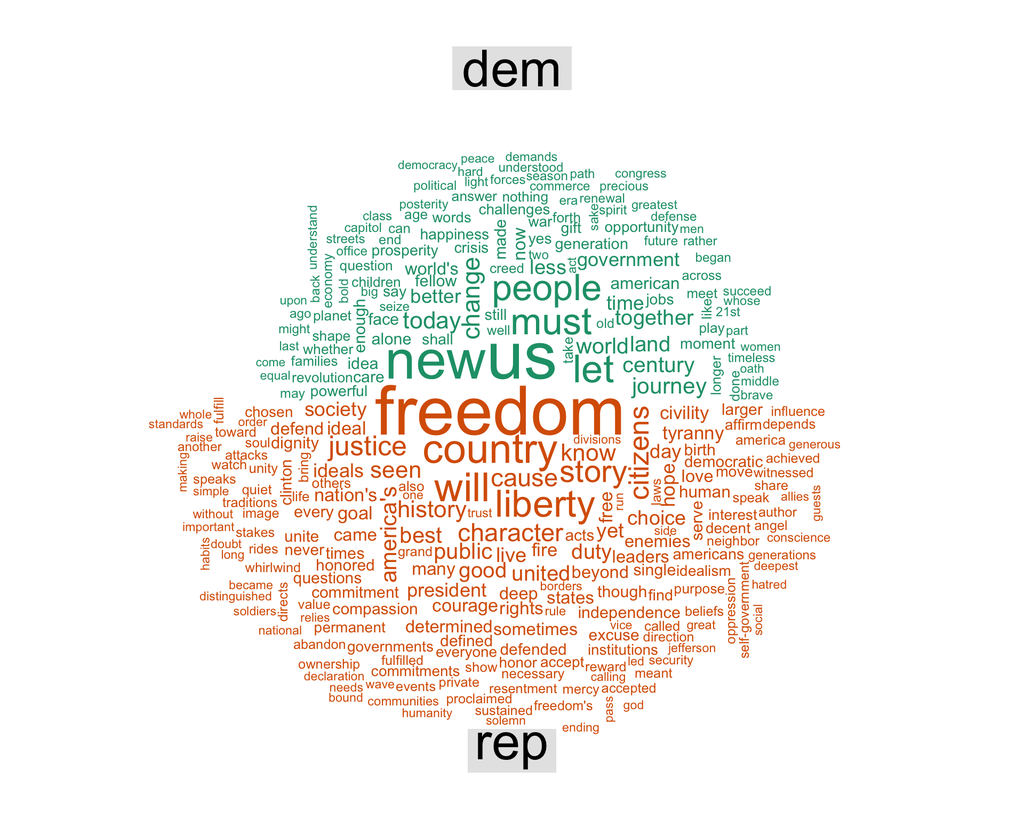

```r
partyDfm <- dfm(recentCorpus, groups = "Party", ignoredFeatures = stopwords("english"),                  verbose = FALSE)
plot(partyDfm, comparison = TRUE)
```